# Trends instructional staff employees in universities

The American Association of University Professors (AAUP) is a nonprofit membership association of faculty and other academic professionals. [This report](https://www.aaup.org/sites/default/files/files/AAUP_Report_InstrStaff-75-11_apr2013.pdf) by the AAUP shows trends in instructional staff employees between 1975 and 2011, and contains the following image. What trends are apparent in this visualization?

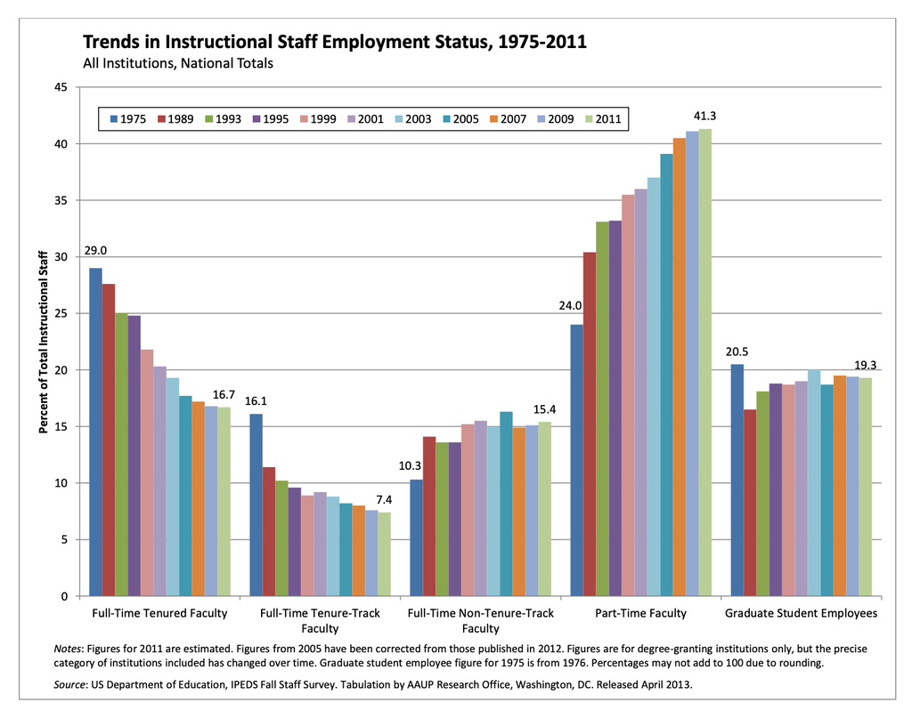

## Packages

```r
library(tidyverse)
library(scales)
library(ggthemes)
```

## Data

```r
staff <- read_csv("https://sta199-s24.github.io/data/instructional-staff.csv")
staff
```

```
# A tibble: 5 × 12
  faculty_type    `1975` `1989` `1993` `1995` `1999` `2001` `2003` `2005` `2007`
  <chr>            <dbl>  <dbl>  <dbl>  <dbl>  <dbl>  <dbl>  <dbl>  <dbl>  <dbl>
1 Full-Time Tenu…   29     27.6   25     24.8   21.8   20.3   19.3   17.8   17.2
2 Full-Time Tenu…   16.1   11.4   10.2    9.6    8.9    9.2    8.8    8.2    8
3 Full-Time Non-…   10.3   14.1   13.6   13.6   15.2   15.5   15     14.8   14.9
4 Part-Time Facu…   24     30.4   33.1   33.2   35.5   36     37     39.3   40.5
5 Graduate Stude…   20.5   16.5   18.1   18.8   18.7   19     20     19.9   19.5
# ℹ 2 more variables: `2009` <dbl>, `2011` <dbl>
```

## Recreate

- **Your turn (10 minutes):** Recreate the visualization above. Try to match as many of the elements as possible. Hint: You might need to reshape your data first.

```r
staff_long <- staff |>
  pivot_longer(
    cols = -faculty_type, names_to = "year",
    values_to = "percentage"
  ) |>
  mutate(
    percentage = as.numeric(percentage),
    faculty_type = fct_relevel(
      faculty_type,
      "Full-Time Tenured Faculty",
      "Full-Time Tenure-Track Faculty",
      "Full-Time Non-Tenure-Track Faculty",
      "Part-Time Faculty",
      "Graduate Student Employees"
    )
  )
```

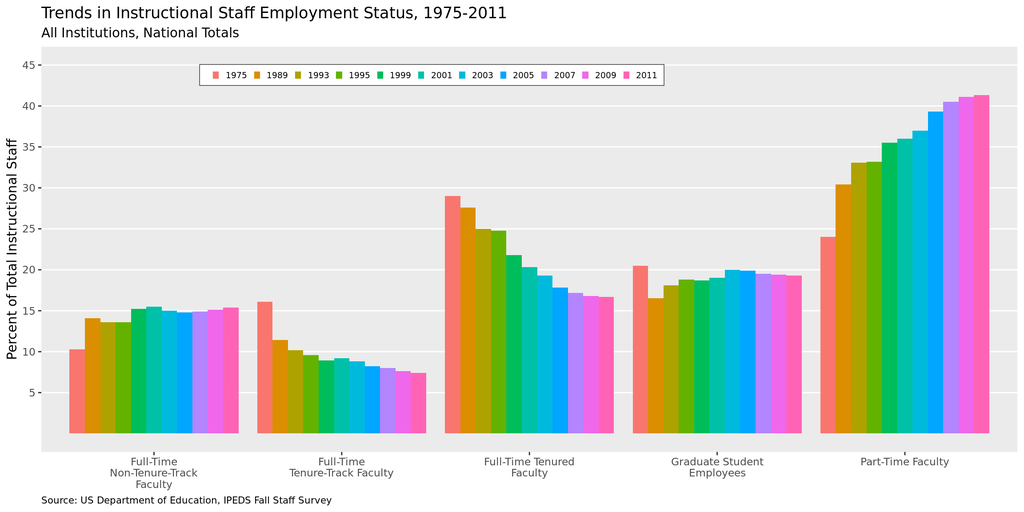

```r
ggplot(
  staff_long,
  aes(
    x = str_wrap(faculty_type, 20),
    y = percentage,
    fill = year
    )
  ) +
  geom_col(position = "dodge") +
  scale_y_continuous(breaks = seq(5, 45, 5), limits = c(0, 45)) +
  labs(
    x = NULL,
    y = "Percent of Total Instructional Staff",
    fill = NULL,
    title = "Trends in Instructional Staff Employment Status, 1975-2011",
    subtitle = "All Institutions, National Totals",
    caption = "Source: US Department of Education, IPEDS Fall Staff Survey"
  ) +
  theme(
    legend.position = c(0.4, 0.93),
    legend.direction = "horizontal",
    legend.key.size = unit(0.2, "cm"),
    legend.key.height = unit(0.1, "cm"),
    legend.text.align = 0,
    legend.background = element_rect(color = "black", linewidth = 0.2),
    legend.text = element_text(size = 7),
    panel.grid.minor = element_blank(),
    panel.grid.major.x = element_blank(),
    plot.caption = element_text(size = 8, hjust = 0)
  ) +
  guides(fill = guide_legend(nrow = 1))
```

## Represent percentages as parts of a whole

- **Demo:** Recreate the previous visualization where the percentages are represented as parts of a whole.

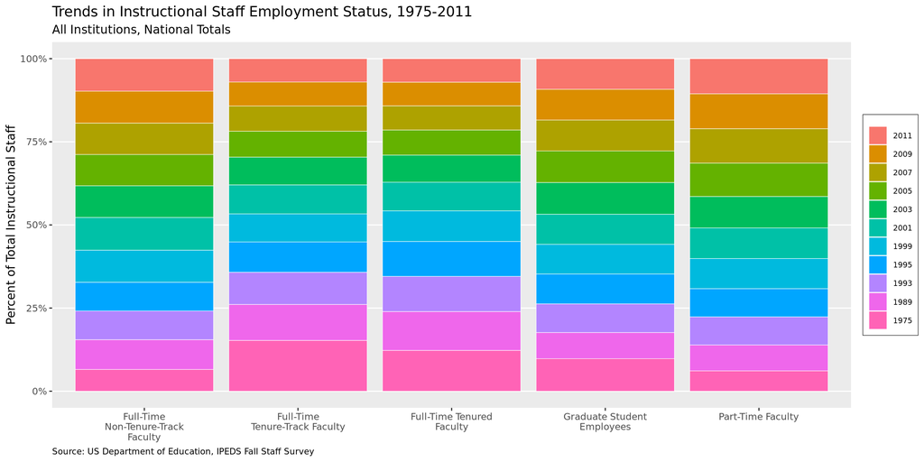

```r
ggplot(
  staff_long,
  aes(
    x = str_wrap(faculty_type, 20),
    y = percentage,
    fill = fct_rev(year)
    )
  ) +
  geom_col(position = "fill", color = "white", linewidth = 0.2) +
  scale_y_continuous(labels = label_percent()) +
  labs(
    x = NULL,
    y = "Percent of Total Instructional Staff",
    fill = NULL,
    title = "Trends in Instructional Staff Employment Status, 1975-2011",
    subtitle = "All Institutions, National Totals",
    caption = "Source: US Department of Education, IPEDS Fall Staff Survey"
  ) +
  theme(
    legend.text.align = 0,
    legend.background = element_rect(color = "black", size = 0.2),
    legend.text = element_text(size = 7),
    panel.grid.minor = element_blank(),
    panel.grid.major.x = element_blank(),
    plot.caption = element_text(size = 8, hjust = 0)
  )
```

## Place time on x-axis

- **Demo:** Convert the visualization to a line plot with time on the x-axis.

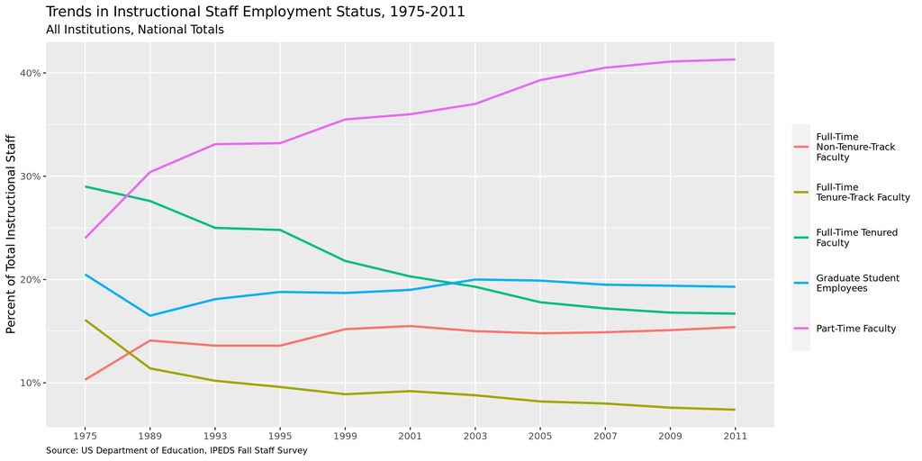

```r
ggplot(
  staff_long,
  aes(
    x = year,
    y = percentage,
    color = str_wrap(faculty_type, 20),
    group = str_wrap(faculty_type, 20)
    )
  ) +
  geom_line(linewidth = 1) +
  labs(
    x = NULL,
    y = "Percent of Total Instructional Staff",
    color = NULL,
    title = "Trends in Instructional Staff Employment Status, 1975-2011",
    subtitle = "All Institutions, National Totals",
    caption = "Source: US Department of Education, IPEDS Fall Staff Survey"
  ) +
  scale_y_continuous(labels = label_percent(accuracy = 1, scale = 1)) +
  theme(
    legend.key.height = unit(1.5, "cm"),
    plot.caption = element_text(size = 8, hjust = 0)
  )
```

## Pay attention to variable types

- **Question:** What is wrong with the x-axis of the plot above? How can you fix it?

Time is represented as a character string (equally spaces between levels) instead of on a continuous scale (with spacing indicating numbers of years between ticks.

- **Your turn:** Implement the fix for the x-axis of the plot.

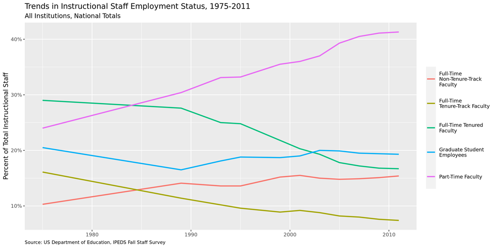

```r
staff_long <- staff_long |>
  mutate(year = as.numeric(year))

ggplot(
  staff_long,
  aes(
    x = year,
    y = percentage,
    color = str_wrap(faculty_type, 20),
    group = str_wrap(faculty_type, 20)
  )
) +
  geom_line(linewidth = 1) +
  labs(
    x = NULL,
    y = "Percent of Total Instructional Staff",
    color = NULL,
    title = "Trends in Instructional Staff Employment Status, 1975-2011",
    subtitle = "All Institutions, National Totals",
    caption = "Source: US Department of Education, IPEDS Fall Staff Survey"
  ) +
  scale_y_continuous(labels = label_percent(accuracy = 1, scale = 1)) +
  theme(
    legend.key.height = unit(1.5, "cm"),
    plot.caption = element_text(size = 8, hjust = 0)
  )
```

## Use an accessible color scale

**Question:** What do we mean by an accessible color scale? What types of color vision deficiencies are there?

- **Demo:** What does the plot look like to people with various color vision deficiencies?
- **Demo:** Remake the plot with an accessible color scale.

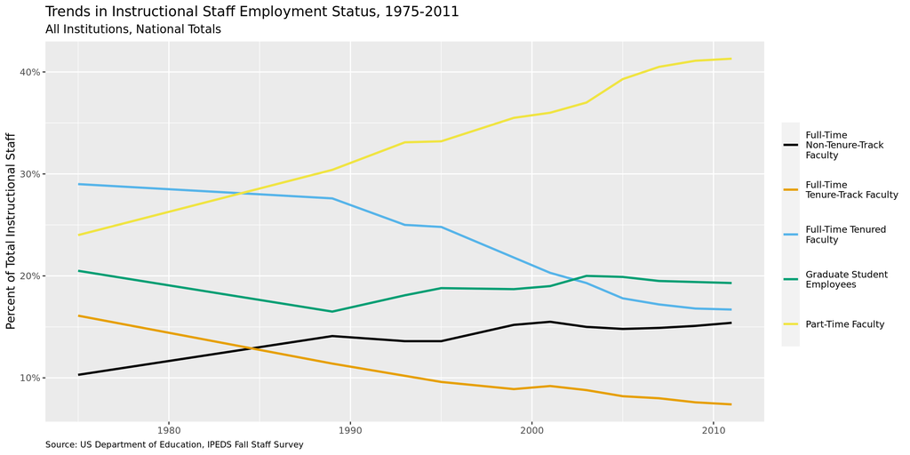

```r
ggplot(
  staff_long,
  aes(
    x = year,
    y = percentage,
    color = str_wrap(faculty_type, 20),
    group = str_wrap(faculty_type, 20)
    )
  ) +
  geom_line(linewidth = 1) +
  labs(
    x = NULL,
    y = "Percent of Total Instructional Staff",
    color = NULL,
    title = "Trends in Instructional Staff Employment Status, 1975-2011",
    subtitle = "All Institutions, National Totals",
    caption = "Source: US Department of Education, IPEDS Fall Staff Survey"
  ) +
  scale_y_continuous(labels = label_percent(accuracy = 1, scale = 1)) +
  theme(
    legend.key.height = unit(1.5, "cm"),
    plot.caption = element_text(size = 8, hjust = 0)
  ) +
  scale_color_colorblind() # from ggthemes package
```

## Use direct labeling

- **Demo:** Remove the legend and add labels for each line at the end of the line (where `x` is the `max(x)` recorded).

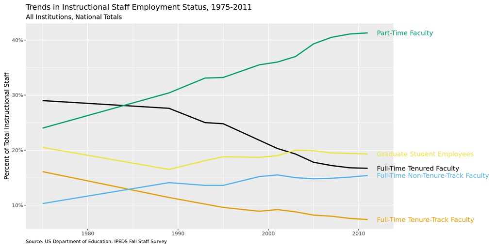

```r
ggplot(
  staff_long,
  aes(
    x = year,
    y = percentage,
    color = faculty_type,
    group = faculty_type
    )
  ) +
  geom_line(linewidth = 1, show.legend = FALSE) +
  geom_text(
    data = staff_long |> filter(year == max(year)),
    aes(x = year + 1, y = percentage, label = faculty_type),
    hjust = "left", show.legend = FALSE, size = 4
  ) +
  labs(
    x = NULL,
    y = "Percent of Total Instructional Staff",
    color = NULL,
    title = "Trends in Instructional Staff Employment Status, 1975-2011",
    subtitle = "All Institutions, National Totals",
    caption = "Source: US Department of Education, IPEDS Fall Staff Survey"
  ) +
  scale_y_continuous(labels = label_percent(accuracy = 1, scale = 1)) +
  theme(
    plot.caption = element_text(size = 8, hjust = 0),
    plot.margin = margin(0.1, 2.5, 0.1, 0.1, unit = "in")
  ) +
  coord_cartesian(clip = "off") +
  scale_color_colorblind()
```

## Use color to draw attention

- **Demo:** Redo the line plot where Part-time Faculty is red and the rest are gray.

```r
staff_long <- staff_long |>
  mutate(faculty_type_color = if_else(faculty_type == "Part-Time Faculty", "firebrick3", "gray40"))
```

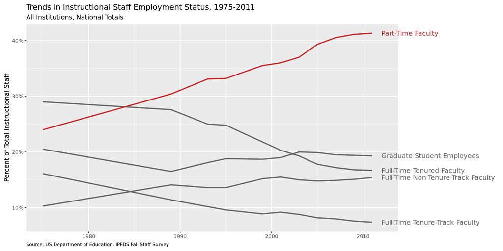

```r
ggplot(
  staff_long,
  aes(
    x = year,
    y = percentage,
    color = faculty_type_color, group = faculty_type
    )
  ) +
  geom_line(linewidth = 1, show.legend = FALSE) +
  geom_text(
    data = staff_long |> filter(year == max(year)),
    aes(x = year + 1, y = percentage, label = faculty_type),
    hjust = "left", show.legend = FALSE, size = 4
  ) +
  labs(
    x = NULL,
    y = "Percent of Total Instructional Staff",
    color = NULL,
    title = "Trends in Instructional Staff Employment Status, 1975-2011",
    subtitle = "All Institutions, National Totals",
    caption = "Source: US Department of Education, IPEDS Fall Staff Survey"
  ) +
  scale_y_continuous(labels = label_percent(accuracy = 1, scale = 1)) +
  scale_color_identity() +
  theme(
    plot.caption = element_text(size = 8, hjust = 0),
    plot.margin = margin(0.1, 2.5, 0.1, 0.1, unit = "in")
  ) +
  coord_cartesian(clip = "off")
```

## Pick a purpose

```r
p <- ggplot(
  staff_long,
  aes(
    x = year,
    y = percentage,
    color = faculty_type_color, group = faculty_type
    )
  ) +
  geom_line(linewidth = 1, show.legend = FALSE) +
  labs(
    x = NULL,
    y = "Percent of Total Instructional Staff",
    color = NULL,
    title = "Trends in Instructional Staff Employment Status, 1975-2011",
    subtitle = "All Institutions, National Totals",
    caption = "Source: US Department of Education, IPEDS Fall Staff Survey"
  ) +
  scale_y_continuous(labels = label_percent(accuracy = 1, scale = 1)) +
  scale_color_identity() +
  theme(
    plot.caption = element_text(size = 8, hjust = 0),
    plot.margin = margin(0.1, 0.6, 0.1, 0.1, unit = "in")
  ) +
  coord_cartesian(clip = "off") +
  annotate(
    geom = "text",
    x = 2012, y = 41, label = "Part-Time\nFaculty",
    color = "firebrick3", hjust = "left", size = 5
  ) +
  annotate(
    geom = "text",
    x = 2012, y = 13.5, label = "Other\nFaculty",
    color = "gray40", hjust = "left", size = 5
  ) +
  annotate(
    geom = "segment",
    x = 2011.5, xend = 2011.5,
    y = 7, yend = 20,
    color = "gray40", linetype = "dotted"
  )
```

## Use labels to communicate the message

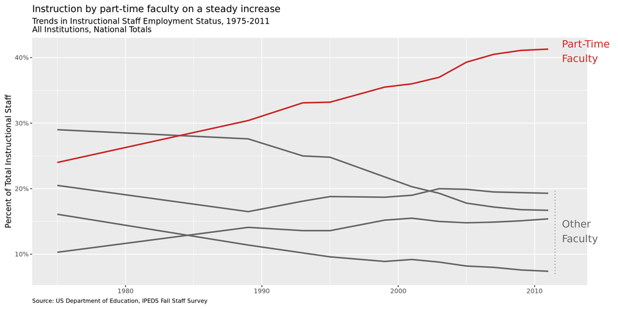

```r
p +
  labs(
    title = "Instruction by part-time faculty on a steady increase",
    subtitle = "Trends in Instructional Staff Employment Status, 1975-2011\nAll Institutions, National Totals",
    caption = "Source: US Department of Education, IPEDS Fall Staff Survey",
    y = "Percent of Total Instructional Staff",
    x = NULL
  )
```

## Simplify

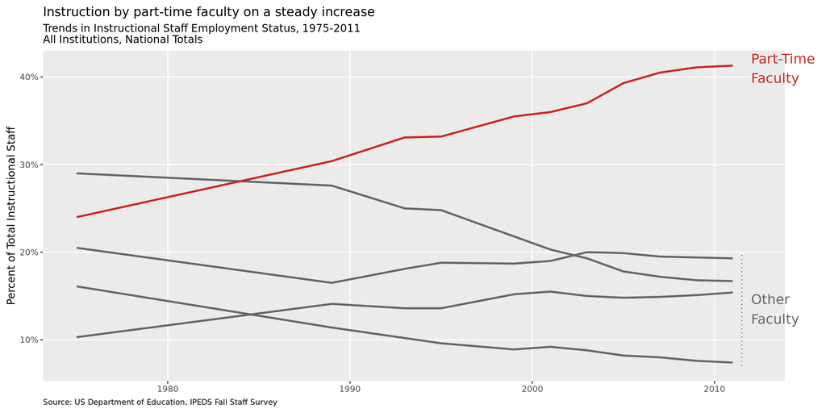

```r
p +
  labs(
    title = "Instruction by part-time faculty on a steady increase",
    subtitle = "Trends in Instructional Staff Employment Status, 1975-2011\nAll Institutions, National Totals",
    caption = "Source: US Department of Education, IPEDS Fall Staff Survey",
    y = "Percent of Total Instructional Staff",
    x = NULL
  ) +
  theme(panel.grid.minor = element_blank())
```

## Summary

- Represent percentages as parts of a whole
- Place variables representing time on the x-axis when possible
- Pay attention to data types, e.g., represent time as time on a continuous scale, not years as levels of a categorical variable
- Prefer direct labeling over legends
- Use accessible colors
- Use color to draw attention
- Pick a purpose and label, color, annotate for that purpose
- Communicate your main message directly in the plot labels
- Simplify before you call it done (a.k.a. “Before you leave the house, look in the mirror and take one thing off”)